# Project 2 Part 1: Exploratory Data Analysis

## 1. Dataset Information

### Dataset Title and Topic

Sports Data Analysis: Analysing official FIFA player statistics and rankings data.

### Data Source

The dataset is sourced from the FIFA player statistics CSV file (`fifa_eda_stats.csv`) on [a Kaggle project](https://www.kaggle.com/datasets/mukeshmanral/fifa-data-for-eda-and-stats), containing player performance metrics and rankings information.

### Real-World Context and Purpose

This dataset represents international football player statistics and rankings, which is valuable for:

- Understanding player performance metrics across different categories
- Analyzing ranking trends and player evaluations
- Supporting sports analytics and player comparison studies

### Dataset Introduction

This dataset contains statistics for 15,000+ FIFA players, sourced from FIFA player ratings data (fifa_eda_stats.csv). It includes 57 columns covering player identity (name, age, nationality, club), financial information (market value, wage, release clause), physical attributes (height, weight), and over 30 in-game skill ratings such as dribbling, passing, shooting, and goalkeeping.

```python
import numpy as np
import pandas as pd
import matplotlib as plt
```

### BASIC DATA EXPLORATION

```python
#Load the dataset
df = pd.read_csv("fifa_eda_stats.csv")
df
```

|  | ID | Name | Age | Nationality | Overall | Potential | Club | Value | Wage | Preferred Foot | ... | Composure | Marking | StandingTackle | SlidingTackle | GKDiving | GKHandling | GKKicking | GKPositioning | GKReflexes | Release Clause |
| --- | --- | --- | --- | --- | --- | --- | --- | --- | --- | --- | --- | --- | --- | --- | --- | --- | --- | --- | --- | --- | --- |
| 0 | 158023 | L. Messi | 31 | Argentina | 94 | 94 | FC Barcelona | €110.5M | €565K | Left | ... | 96.0 | 33.0 | 28.0 | 26.0 | 6.0 | 11.0 | 15.0 | 14.0 | 8.0 | €226.5M |
| 1 | 20801 | Cristiano Ronaldo | 33 | Portugal | 94 | 94 | Juventus | €77M | €405K | Right | ... | 95.0 | 28.0 | 31.0 | 23.0 | 7.0 | 11.0 | 15.0 | 14.0 | 11.0 | €127.1M |
| 2 | 190871 | Neymar Jr | 26 | Brazil | 92 | 93 | Paris Saint-Germain | €118.5M | €290K | Right | ... | 94.0 | 27.0 | 24.0 | 33.0 | 9.0 | 9.0 | 15.0 | 15.0 | 11.0 | €228.1M |
| 3 | 193080 | De Gea | 27 | Spain | 91 | 93 | Manchester United | €72M | €260K | Right | ... | 68.0 | 15.0 | 21.0 | 13.0 | 90.0 | 85.0 | 87.0 | 88.0 | 94.0 | €138.6M |
| 4 | 192985 | K. De Bruyne | 27 | Belgium | 91 | 92 | Manchester City | €102M | €355K | Right | ... | 88.0 | 68.0 | 58.0 | 51.0 | 15.0 | 13.0 | 5.0 | 10.0 | 13.0 | €196.4M |
| ... | ... | ... | ... | ... | ... | ... | ... | ... | ... | ... | ... | ... | ... | ... | ... | ... | ... | ... | ... | ... | ... |
| 18202 | 238813 | J. Lundstram | 19 | England | 47 | 65 | Crewe Alexandra | €60K | €1K | Right | ... | 45.0 | 40.0 | 48.0 | 47.0 | 10.0 | 13.0 | 7.0 | 8.0 | 9.0 | €143K |
| 18203 | 243165 | N. Christoffersson | 19 | Sweden | 47 | 63 | Trelleborgs FF | €60K | €1K | Right | ... | 42.0 | 22.0 | 15.0 | 19.0 | 10.0 | 9.0 | 9.0 | 5.0 | 12.0 | €113K |
| 18204 | 241638 | B. Worman | 16 | England | 47 | 67 | Cambridge United | €60K | €1K | Right | ... | 41.0 | 32.0 | 13.0 | 11.0 | 6.0 | 5.0 | 10.0 | 6.0 | 13.0 | €165K |
| 18205 | 246268 | D. Walker-Rice | 17 | England | 47 | 66 | Tranmere Rovers | €60K | €1K | Right | ... | 46.0 | 20.0 | 25.0 | 27.0 | 14.0 | 6.0 | 14.0 | 8.0 | 9.0 | €143K |
| 18206 | 246269 | G. Nugent | 16 | England | 46 | 66 | Tranmere Rovers | €60K | €1K | Right | ... | 43.0 | 40.0 | 43.0 | 50.0 | 10.0 | 15.0 | 9.0 | 12.0 | 9.0 | €165K |

18207 rows × 57 columns

```python
#First five rows of the dataset
df.head()
```

|  | ID | Name | Age | Nationality | Overall | Potential | Club | Value | Wage | Preferred Foot | ... | Composure | Marking | StandingTackle | SlidingTackle | GKDiving | GKHandling | GKKicking | GKPositioning | GKReflexes | Release Clause |
| --- | --- | --- | --- | --- | --- | --- | --- | --- | --- | --- | --- | --- | --- | --- | --- | --- | --- | --- | --- | --- | --- |
| 0 | 158023 | L. Messi | 31 | Argentina | 94 | 94 | FC Barcelona | €110.5M | €565K | Left | ... | 96.0 | 33.0 | 28.0 | 26.0 | 6.0 | 11.0 | 15.0 | 14.0 | 8.0 | €226.5M |
| 1 | 20801 | Cristiano Ronaldo | 33 | Portugal | 94 | 94 | Juventus | €77M | €405K | Right | ... | 95.0 | 28.0 | 31.0 | 23.0 | 7.0 | 11.0 | 15.0 | 14.0 | 11.0 | €127.1M |
| 2 | 190871 | Neymar Jr | 26 | Brazil | 92 | 93 | Paris Saint-Germain | €118.5M | €290K | Right | ... | 94.0 | 27.0 | 24.0 | 33.0 | 9.0 | 9.0 | 15.0 | 15.0 | 11.0 | €228.1M |
| 3 | 193080 | De Gea | 27 | Spain | 91 | 93 | Manchester United | €72M | €260K | Right | ... | 68.0 | 15.0 | 21.0 | 13.0 | 90.0 | 85.0 | 87.0 | 88.0 | 94.0 | €138.6M |
| 4 | 192985 | K. De Bruyne | 27 | Belgium | 91 | 92 | Manchester City | €102M | €355K | Right | ... | 88.0 | 68.0 | 58.0 | 51.0 | 15.0 | 13.0 | 5.0 | 10.0 | 13.0 | €196.4M |

5 rows × 57 columns

```python
#Last five rows of the dataset
df.tail()
```

|  | ID | Name | Age | Nationality | Overall | Potential | Club | Value | Wage | Preferred Foot | ... | Composure | Marking | StandingTackle | SlidingTackle | GKDiving | GKHandling | GKKicking | GKPositioning | GKReflexes | Release Clause |
| --- | --- | --- | --- | --- | --- | --- | --- | --- | --- | --- | --- | --- | --- | --- | --- | --- | --- | --- | --- | --- | --- |
| 18202 | 238813 | J. Lundstram | 19 | England | 47 | 65 | Crewe Alexandra | €60K | €1K | Right | ... | 45.0 | 40.0 | 48.0 | 47.0 | 10.0 | 13.0 | 7.0 | 8.0 | 9.0 | €143K |
| 18203 | 243165 | N. Christoffersson | 19 | Sweden | 47 | 63 | Trelleborgs FF | €60K | €1K | Right | ... | 42.0 | 22.0 | 15.0 | 19.0 | 10.0 | 9.0 | 9.0 | 5.0 | 12.0 | €113K |
| 18204 | 241638 | B. Worman | 16 | England | 47 | 67 | Cambridge United | €60K | €1K | Right | ... | 41.0 | 32.0 | 13.0 | 11.0 | 6.0 | 5.0 | 10.0 | 6.0 | 13.0 | €165K |
| 18205 | 246268 | D. Walker-Rice | 17 | England | 47 | 66 | Tranmere Rovers | €60K | €1K | Right | ... | 46.0 | 20.0 | 25.0 | 27.0 | 14.0 | 6.0 | 14.0 | 8.0 | 9.0 | €143K |
| 18206 | 246269 | G. Nugent | 16 | England | 46 | 66 | Tranmere Rovers | €60K | €1K | Right | ... | 43.0 | 40.0 | 43.0 | 50.0 | 10.0 | 15.0 | 9.0 | 12.0 | 9.0 | €165K |

5 rows × 57 columns

```python
#Rows and Columns
print("Rows and Columns: ", df.shape)
```

```
Rows and Columns:  (18207, 57)
```

```python
#Column Names
list(df.columns)
```

```
['ID',
 'Name',
 'Age',
 'Nationality',
 'Overall',
 'Potential',
 'Club',
 'Value',
 'Wage',
 'Preferred Foot',
 'International Reputation',
 'Weak Foot',
 'Skill Moves',
 'Work Rate',
 'Body Type',
 'Position',
 'Jersey Number',
 'Joined',
 'Loaned From',
 'Contract Valid Until',
 'Height',
 'Weight',
 'Crossing',
 'Finishing',
 'HeadingAccuracy',
 'ShortPassing',
 'Volleys',
 'Dribbling',
 'Curve',
 'FKAccuracy',
 'LongPassing',
 'BallControl',
 'Acceleration',
 'SprintSpeed',
 'Agility',
 'Reactions',
 'Balance',
 'ShotPower',
 'Jumping',
 'Stamina',
 'Strength',
 'LongShots',
 'Aggression',
 'Interceptions',
 'Positioning',
 'Vision',
 'Penalties',
 'Composure',
 'Marking',
 'StandingTackle',
 'SlidingTackle',
 'GKDiving',
 'GKHandling',
 'GKKicking',
 'GKPositioning',
 'GKReflexes',
 'Release Clause']
```

### Data Types and Structure

```python
#Summary of data
df.info()
```

```
<class 'pandas.core.frame.DataFrame'>
RangeIndex: 18207 entries, 0 to 18206
Data columns (total 57 columns):
 #   Column                    Non-Null Count  Dtype
---  ------                    --------------  -----
 0   ID                        18207 non-null  int64
 1   Name                      18207 non-null  object
 2   Age                       18207 non-null  int64
 3   Nationality               18207 non-null  object
 4   Overall                   18207 non-null  int64
 5   Potential                 18207 non-null  int64
 6   Club                      17966 non-null  object
 7   Value                     18207 non-null  object
 8   Wage                      18207 non-null  object
 9   Preferred Foot            18159 non-null  object
```

[output cut: 49 more lines]

```python
numerical_columns = df.select_dtypes(include=['number'])
object_columns = df.select_dtypes(include=['object'])

print(f"Numerical Columns are: {list(numerical_columns)}")
print(f"Object Columns are: {list(object_columns)}")
```

```
Numerical Columns are: ['ID', 'Age', 'Overall', 'Potential', 'International Reputation', 'Weak Foot', 'Skill Moves', 'Jersey Number', 'Crossing', 'Finishing', 'HeadingAccuracy', 'ShortPassing', 'Volleys', 'Dribbling', 'Curve', 'FKAccuracy', 'LongPassing', 'BallControl', 'Acceleration', 'SprintSpeed'…
Object Columns are: ['Name', 'Nationality', 'Club', 'Value', 'Wage', 'Preferred Foot', 'Work Rate', 'Body Type', 'Position', 'Joined', 'Loaned From', 'Contract Valid Until', 'Height', 'Weight', 'Release Clause']
```

### Data Type Conversion

Several columns need their data types converted before analysis. Value, Wage, and Release Clause are currently stored as strings because of the currency symbol and suffixes (e.g. "€110.5M"), so the symbol and letters need to be stripped and the values converted to floats. Similarly, Height is stored as a string in feet and inches format (e.g. "5'7"") and Weight has a "lbs" suffix so both need to be converted to plain numbers so they can be used for numerical analysis. Joined and Contract Valid Until are date strings that should be converted to datetime so they can be used in time-based analysis.

### Descriptive Statistics

```python
#Summary Statsitcs
df.describe()
```

|  | ID | Age | Overall | Potential | International Reputation | Weak Foot | Skill Moves | Jersey Number | Crossing | Finishing | ... | Penalties | Composure | Marking | StandingTackle | SlidingTackle | GKDiving | GKHandling | GKKicking | GKPositioning | GKReflexes |
| --- | --- | --- | --- | --- | --- | --- | --- | --- | --- | --- | --- | --- | --- | --- | --- | --- | --- | --- | --- | --- | --- |
| count | 18207.000000 | 18207.000000 | 18207.000000 | 18207.000000 | 18159.000000 | 18159.000000 | 18159.000000 | 18147.000000 | 18159.000000 | 18159.000000 | ... | 18159.000000 | 18159.000000 | 18159.000000 | 18159.000000 | 18159.000000 | 18159.000000 | 18159.000000 | 18159.000000 | 18159.000000 | 18159.000000 |
| mean | 214298.338606 | 25.122206 | 66.238699 | 71.307299 | 1.113222 | 2.947299 | 2.361308 | 19.546096 | 49.734181 | 45.550911 | ... | 48.548598 | 58.648274 | 47.281623 | 47.697836 | 45.661435 | 16.616223 | 16.391596 | 16.232061 | 16.388898 | 16.710887 |
| std | 29965.244204 | 4.669943 | 6.908930 | 6.136496 | 0.394031 | 0.660456 | 0.756164 | 15.947765 | 18.364524 | 19.525820 | ... | 15.704053 | 11.436133 | 19.904397 | 21.664004 | 21.289135 | 17.695349 | 16.906900 | 16.502864 | 17.034669 | 17.955119 |
| min | 16.000000 | 16.000000 | 46.000000 | 48.000000 | 1.000000 | 1.000000 | 1.000000 | 1.000000 | 5.000000 | 2.000000 | ... | 5.000000 | 3.000000 | 3.000000 | 2.000000 | 3.000000 | 1.000000 | 1.000000 | 1.000000 | 1.000000 | 1.000000 |
| 25% | 200315.500000 | 21.000000 | 62.000000 | 67.000000 | 1.000000 | 3.000000 | 2.000000 | 8.000000 | 38.000000 | 30.000000 | ... | 39.000000 | 51.000000 | 30.000000 | 27.000000 | 24.000000 | 8.000000 | 8.000000 | 8.000000 | 8.000000 | 8.000000 |
| 50% | 221759.000000 | 25.000000 | 66.000000 | 71.000000 | 1.000000 | 3.000000 | 2.000000 | 17.000000 | 54.000000 | 49.000000 | ... | 49.000000 | 60.000000 | 53.000000 | 55.000000 | 52.000000 | 11.000000 | 11.000000 | 11.000000 | 11.000000 | 11.000000 |
| 75% | 236529.500000 | 28.000000 | 71.000000 | 75.000000 | 1.000000 | 3.000000 | 3.000000 | 26.000000 | 64.000000 | 62.000000 | ... | 60.000000 | 67.000000 | 64.000000 | 66.000000 | 64.000000 | 14.000000 | 14.000000 | 14.000000 | 14.000000 | 14.000000 |
| max | 246620.000000 | 45.000000 | 94.000000 | 95.000000 | 5.000000 | 5.000000 | 5.000000 | 99.000000 | 93.000000 | 95.000000 | ... | 92.000000 | 96.000000 | 94.000000 | 93.000000 | 91.000000 | 90.000000 | 92.000000 | 91.000000 | 90.000000 | 94.000000 |

8 rows × 42 columns

`Overall` Column Intepretation:  
The `Overall` column has a mean of 66.2, median of 66, min of 46, max of 94, and a standard deviation of ~6.9. The mean and median being almost equal tells us the distribution is fairly symmetric with no strong skew. The std of ~7 means most players fall within a 14-point band around the average, and the full range of 48 points (46–94) covers everything from unpolished youth players to world-class talent like Messi and Ronaldo.

```python
for col in list(numerical_columns):
    print(f"Mean for {col} column: {df[col].mean()}")
    print(f"Median for {col} column: {df[col].median()}")
    print(f"Range for {col} column: {df[col].max() - df[col].min()}")
    print()
```

```
Mean for ID column: 214298.33860603065
Median for ID column: 221759.0
Range for ID column: 246604

Mean for Age column: 25.122205745043114
Median for Age column: 25.0
Range for Age column: 29

Mean for Overall column: 66.23869940132916
Median for Overall column: 66.0
Range for Overall column: 48

Mean for Potential column: 71.30729939034437
Median for Potential column: 71.0
Range for Potential column: 47

Mean for International Reputation column: 1.1132220937276283
Median for International Reputation column: 1.0
Range for International Reputation column: 4.0

Mean for Weak Foot column: 2.9472988600693872
Median for Weak Foot column: 3.0
Range for Weak Foot column: 4.0

Mean for Skill Moves column: 2.361308442094829
Median for Skill Moves column: 2.0
Range for Skill Moves column: 4.0

Mean for Jersey Number column: 19.546095773406073
Median for Jersey Number column: 17.0
Range for Jersey Number column: 98.0

Mean for Crossing column: 49.734181397654055
Median for Crossing column: 54.0
Range for Crossing column: 88.0

Mean for Finishing column: 45.55091139379922
Median for Finishing column: 49.0
Range for Finishing column: 93.0

```

[output cut: 112 more lines]

```
Mean for GKHandling column: 16.391596453549205
Median for GKHandling column: 11.0
Range for GKHandling column: 91.0

Mean for GKKicking column: 16.23206123685225
Median for GKKicking column: 11.0
Range for GKKicking column: 90.0

Mean for GKPositioning column: 16.388898067074177
Median for GKPositioning column: 11.0
Range for GKPositioning column: 89.0

Mean for GKReflexes column: 16.710887163390055
Median for GKReflexes column: 11.0
Range for GKReflexes column: 93.0
```

**What the statistics tell us about the numerical columns generally:** Most skill columns (Crossing, Dribbling, ShortPassing, etc.) have means in the 45–65 range with standard deviations of 15–20, indicating moderate spread and a roughly normal distribution around an average player. Columns like `Acceleration`, `SprintSpeed`, `Strength`, and `Jumping` all have means above 60, suggesting these physical attributes are rated higher on average than technical ones like `FKAccuracy` (mean of 43) or `Volleys` (mean of 43).

**Columns with unusual or inconsistent values:**

- **GK stats** (`GKDiving`, `GKHandling`, `GKKicking`, `GKPositioning`, `GKReflexes`): Mean ~16 and median ~11 but max values above 90. This is because outfield players all score near zero on these, while only goalkeepers score well or very highly. It shows that the column is bimodal and misleading if analysed as a whole.
- **`Jersey Number`**: Max of 99 with a mean of ~19.5 — the high values come from reserve and youth squad numbers, which inflates the range significantly.

### Missing Data or Handling Duplicates

```python
df.isna().sum()
```

```
ID                              0
Name                            0
Age                             0
Nationality                     0
Overall                         0
Potential                       0
Club                          241
Value                           0
Wage                            0
Preferred Foot                 48
International Reputation       48
Weak Foot                      48
Skill Moves                    48
Work Rate                      48
Body Type                      48
Position                       60
Jersey Number                  60
Joined                       1553
Loaned From                 16943
Contract Valid Until          289
Height                         48
Weight                         48
Crossing                       48
Finishing                      48
HeadingAccuracy                48
ShortPassing                   48
Volleys                        48
Dribbling                      48
Curve                          48
FKAccuracy                     48
LongPassing                    48
BallControl                    48
Acceleration                   48
SprintSpeed                    48
Agility                        48
Reactions                      48
Balance                        48
ShotPower                      48
Jumping                        48
Stamina                        48
Strength                       48
LongShots                      48
Aggression                     48
Interceptions                  48
Positioning                    48
Vision                         48
Penalties                      48
Composure                      48
Marking                        48
StandingTackle                 48
SlidingTackle                  48
GKDiving                       48
GKHandling                     48
GKKicking                      48
GKPositioning                  48
GKReflexes                     48
Release Clause               1564
dtype: int64
```

The `Loaned From` column has 16,943 missing values out of 18,207 rows. The column ,however, is only populated for players currently on loan (which are 1,264 players, ~7% of the dataset). Missing values here do not represent a data quality problem; they simply mean the player is permanently registered with their club. We just need to replace to missing values with text to indicate that.

```python
#check for duplicate values
print(df.duplicated().sum())
```

```
0
```

```python
#Verify the 48 missing rows are the same across all affected columns
cols_with_48 = ['Preferred Foot', 'International Reputation', 'Weak Foot', 'Skill Moves',
                'Work Rate', 'Body Type', 'Height', 'Weight', 'Crossing', 'Finishing',
                'HeadingAccuracy', 'ShortPassing', 'Volleys', 'Dribbling', 'Curve',
                'FKAccuracy', 'LongPassing', 'BallControl', 'Acceleration', 'SprintSpeed',
                'Agility', 'Reactions', 'Balance', 'ShotPower', 'Jumping', 'Stamina',
                'Strength', 'LongShots', 'Aggression', 'Interceptions', 'Positioning',
                'Vision', 'Penalties', 'Composure', 'Marking', 'StandingTackle',
                'SlidingTackle', 'GKDiving', 'GKHandling', 'GKKicking', 'GKPositioning',
                'GKReflexes']

missing_sets = {col: set(df[df[col].isna()].index) for col in cols_with_48}
reference = missing_sets['Crossing']

all_same = all(s == reference for s in missing_sets.values())
print(f"All {len(cols_with_48)} columns share the exact same 48 missing rows: {all_same}")
```

```
All 42 columns share the exact same 48 missing rows: True
```

### Data Quality Observations

Looking at the missing values, most columns are in good shape. The skill stat columns (Crossing, Dribbling, etc.) along with Height, Weight, Preferred Foot and others all have the same 48 rows missing. These are incomplete player profiles that we will need to drop entirely. Club has 241 missing values which just means those players are free agents, so we fill those with "Free Agent". Loaned From has the most missing values at 16,943 (93%) but this is expected as it only applies to players currently on loan, so the rest can be filled with "Not on Loan". Position and Jersey Number have 60 missing values each and we can fill with "Unknown" and the median respectively. Joined, Contract Valid Until, and Release Clause might need to be left missing or dropped entirely since these cannot be reliably guessed or imputed. No duplicate rows were found in the dataset.

## Strategy to handle missing data for dataset

- 48 rows missing all skill stats + Height/Weight/Preferred Foot so dropping these rows entirely (incomplete profiles, not salvageable)
- Club column (241) — fill with "Free Agent"
- Loaned From (16,943) — fill with "Not on Loan" (it's structural, not missing data)
- Joined / Contract Valid Until / Release Clause — leave as NaN (can't reliably impute contract dates/clauses)

```python
#Make a copy of the original dataset to work with for cleaning
df_cleaned = df.copy()
```

Dropping the 48 rows where skill stats, Height, Weight, and Preferred Foot are all missing

```python
rows_before = len(df_cleaned)

df_cleaned = df_cleaned.dropna(subset=['Crossing'])

rows_after = len(df_cleaned)
print(f"Dropped: {rows_before - rows_after} rows")
print(f"Remaining rows: {rows_after}")
```

```
Dropped: 48 rows
Remaining rows: 18159
```

241 players have no club (free agents) so we filling with "Free Agent" to keep their rows.

```python
df_cleaned['Club'] = df_cleaned['Club'].fillna('Free Agent')
print("Club missing after fill:", df_cleaned['Club'].isna().sum())
```

```
Club missing after fill: 0
```

Only ~7% of players are on loan, so `Loaned From` is structurally empty for the rest so we can fill with "Not on Loan".

```python
df_cleaned['Loaned From'] = df_cleaned['Loaned From'].fillna('Not on Loan')
print("Loaned From missing after fill:", df_cleaned['Loaned From'].isna().sum())
```

```
Loaned From missing after fill: 0
```

```python
print('Position missing:', df_cleaned['Position'].isna().sum())
print('Jersey Number missing:', df_cleaned['Jersey Number'].isna().sum())
```

```
Position missing: 12
Jersey Number missing: 12
```

After the drop, 12 players still lack these. Fill `Position` with `"Unknown"` and `Jersey Number` with the median.

```python
df_cleaned['Position'] = df_cleaned['Position'].fillna('Unknown')
df_cleaned['Jersey Number'] = df_cleaned['Jersey Number'].fillna(df_cleaned['Jersey Number'].median())

print('Position missing:', df_cleaned['Position'].isna().sum())
print('Jersey Number missing:', df_cleaned['Jersey Number'].isna().sum())
```

```
Position missing: 0
Jersey Number missing: 0
```

### Converting currency columns to numeric

Stripping currency strinhgs and convert suffixes to float values in euros.

```python
def parse_currency(val):
    if pd.isna(val):
        return np.nan
    val = str(val).replace('€', '').strip()
    if 'M' in val:
        return float(val.replace('M', '')) * 1_000_000
    elif 'K' in val:
        return float(val.replace('K', '')) * 1_000
    else:
        return float(val)

df_cleaned['Value'] = df_cleaned['Value'].apply(parse_currency)
df_cleaned['Wage'] = df_cleaned['Wage'].apply(parse_currency)
df_cleaned['Release Clause'] = df_cleaned['Release Clause'].apply(parse_currency)

print(df_cleaned[['Value', 'Wage', 'Release Clause']].dtypes)
df_cleaned[['Value', 'Wage', 'Release Clause']].head()
```

```
Value             float64
Wage              float64
Release Clause    float64
dtype: object
```

|  | Value | Wage | Release Clause |
| --- | --- | --- | --- |
| 0 | 110500000.0 | 565000.0 | 226500000.0 |
| 1 | 77000000.0 | 405000.0 | 127100000.0 |
| 2 | 118500000.0 | 290000.0 | 228100000.0 |
| 3 | 72000000.0 | 260000.0 | 138600000.0 |
| 4 | 102000000.0 | 355000.0 | 196400000.0 |

#### Converting `Height` and `Weight` to numeric

```python
def parse_height(h):
    if pd.isna(h):
        return np.nan
    parts = str(h).replace('"', '').split("'")
    feet = int(parts[0])
    inches = int(parts[1]) if len(parts) > 1 and parts[1] else 0
    return round((feet * 12 + inches) * 2.54, 2)

def parse_weight(w):
    if pd.isna(w):
        return np.nan
    return float(str(w).replace('lbs', ''))

df_cleaned['Height_cm'] = df_cleaned['Height'].apply(parse_height)
df_cleaned['Weight_lbs'] = df_cleaned['Weight'].apply(parse_weight)

print(df_cleaned[['Height_cm', 'Weight_lbs']].describe())
```

```
          Height_cm    Weight_lbs
count  18159.000000  18159.000000
mean     181.257584    165.979129
std        6.730145     15.593344
min      154.940000    110.000000
25%      175.260000    154.000000
50%      180.340000    165.000000
75%      185.420000    176.000000
max      205.740000    243.000000
```

### Converting date columns to datetime

```python
df_cleaned['Joined'] = pd.to_datetime(df_cleaned['Joined'].astype(str))
df_cleaned['Contract Valid Until'] = pd.to_datetime(df_cleaned['Contract Valid Until'].astype(str), errors='coerce')

print(df_cleaned[['Joined', 'Contract Valid Until']].dtypes)
```

```
Joined                  datetime64[ns]
Contract Valid Until    datetime64[ns]
dtype: object
```

#### Exporting the cleaned values and checking if there are more missing values (release clause, joined, contract valid are exceptions)

```python
print("=== Remaining missing values ===")
remaining = df_cleaned.isna().sum()
print(remaining[remaining > 0])
print(f"\nFinal shape: {df_cleaned.shape}")

df_cleaned.to_csv("fifa_eda_stats_cleaned.csv", index=False)
print("\nCleaned dataset saved as fifa_eda_stats_cleaned.csv")
```

```
=== Remaining missing values ===
Joined                  1505
Contract Valid Until    1505
Release Clause          1516
dtype: int64

Final shape: (18159, 59)
```

```
Cleaned dataset saved as fifa_eda_stats_cleaned.csv
```

## Part 2: Data Wrangling

### 6. Add a New Column: BMI

BMI (Body Mass Index) = weight in kg / (height in metres) squared. It gives a standardised measure of a player's body composition relative to their size, useful for comparing physical profiles across positions.

```python
# Weight_lbs → kg, Height_cm → metres
df_cleaned['Weight_kg'] = df_cleaned['Weight_lbs'] * 0.453592
df_cleaned['BMI'] = df_cleaned['Weight_kg'] / ((df_cleaned['Height_cm'] / 100) ** 2)

df_cleaned[['Name', 'Height_cm', 'Weight_lbs', 'Weight_kg', 'BMI']].head()
```

|  | Name | Height_cm | Weight_lbs | Weight_kg | BMI |
| --- | --- | --- | --- | --- | --- |
| 0 | L. Messi | 170.18 | 159.0 | 72.121128 | 24.902645 |
| 1 | Cristiano Ronaldo | 187.96 | 183.0 | 83.007336 | 23.495549 |
| 2 | Neymar Jr | 175.26 | 150.0 | 68.038800 | 22.150882 |
| 3 | De Gea | 193.04 | 168.0 | 76.203456 | 20.449376 |
| 4 | K. De Bruyne | 180.34 | 154.0 | 69.853168 | 21.478402 |

### 7. Filter the Data

**Filter 1:** World Class (Overall ≥ 88)- It is helpful to know the players who are the top tier of world football.

**Filter 2:** Young high-potential players (Age ≤ 23 and Potential ≥ 88) — It is helpful to spot prospects likely to develop into world-class talent, useful for scouting analysis.

```python
# Filter 1: World Class players
wc = df_cleaned[df_cleaned['Overall'] >= 88]
print(f'World Class players (Overall >= 88): {len(wc)}')
wc[['Name', 'Age', 'Nationality', 'Club', 'Overall']]
```

```
World Class players (Overall >= 88): 42
```

|  | Name | Age | Nationality | Club | Overall |
| --- | --- | --- | --- | --- | --- |
| 0 | L. Messi | 31 | Argentina | FC Barcelona | 94 |
| 1 | Cristiano Ronaldo | 33 | Portugal | Juventus | 94 |
| 2 | Neymar Jr | 26 | Brazil | Paris Saint-Germain | 92 |
| 3 | De Gea | 27 | Spain | Manchester United | 91 |
| 4 | K. De Bruyne | 27 | Belgium | Manchester City | 91 |
| 5 | E. Hazard | 27 | Belgium | Chelsea | 91 |
| 6 | L. Modrić | 32 | Croatia | Real Madrid | 91 |
| 7 | L. Suárez | 31 | Uruguay | FC Barcelona | 91 |
| 8 | Sergio Ramos | 32 | Spain | Real Madrid | 91 |
| 9 | J. Oblak | 25 | Slovenia | Atlético Madrid | 90 |
| 10 | R. Lewandowski | 29 | Poland | FC Bayern München | 90 |
| 11 | T. Kroos | 28 | Germany | Real Madrid | 90 |
| 12 | D. Godín | 32 | Uruguay | Atlético Madrid | 90 |
| 13 | David Silva | 32 | Spain | Manchester City | 90 |
| 14 | N. Kanté | 27 | France | Chelsea | 89 |
| 15 | P. Dybala | 24 | Argentina | Juventus | 89 |
| 16 | H. Kane | 24 | England | Tottenham Hotspur | 89 |
| 17 | A. Griezmann | 27 | France | Atlético Madrid | 89 |
| 18 | M. ter Stegen | 26 | Germany | FC Barcelona | 89 |
| 19 | T. Courtois | 26 | Belgium | Real Madrid | 89 |
| 20 | Sergio Busquets | 29 | Spain | FC Barcelona | 89 |
| 21 | E. Cavani | 31 | Uruguay | Paris Saint-Germain | 89 |
| 22 | M. Neuer | 32 | Germany | FC Bayern München | 89 |
| 23 | S. Agüero | 30 | Argentina | Manchester City | 89 |
| 24 | G. Chiellini | 33 | Italy | Juventus | 89 |
| 25 | K. Mbappé | 19 | France | Paris Saint-Germain | 88 |
| 26 | M. Salah | 26 | Egypt | Liverpool | 88 |
| 27 | Casemiro | 26 | Brazil | Real Madrid | 88 |
| 28 | J. Rodríguez | 26 | Colombia | FC Bayern München | 88 |
| 29 | L. Insigne | 27 | Italy | Napoli | 88 |
| 30 | Isco | 26 | Spain | Real Madrid | 88 |
| 31 | C. Eriksen | 26 | Denmark | Tottenham Hotspur | 88 |
| 32 | Coutinho | 26 | Brazil | FC Barcelona | 88 |
| 33 | P. Aubameyang | 29 | Gabon | Arsenal | 88 |
| 34 | M. Hummels | 29 | Germany | FC Bayern München | 88 |
| 35 | Marcelo | 30 | Brazil | Real Madrid | 88 |
| 36 | G. Bale | 28 | Wales | Real Madrid | 88 |
| 37 | H. Lloris | 31 | France | Tottenham Hotspur | 88 |
| 38 | G. Higuaín | 30 | Argentina | Milan | 88 |
| 39 | Thiago Silva | 33 | Brazil | Paris Saint-Germain | 88 |
| 40 | S. Handanovič | 33 | Slovenia | Inter | 88 |
| 41 | G. Buffon | 40 | Italy | Paris Saint-Germain | 88 |

```python
# Filter 2: Young high-potential players
young_prospects = df_cleaned[(df_cleaned['Age'] <= 23) & (df_cleaned['Potential'] >= 88)]
print(f'Young high-potential players (Age <= 23, Potential >= 88): {len(young_prospects)}')
young_prospects[['Name', 'Age', 'Nationality', 'Club', 'Overall', 'Potential']]
```

```
Young high-potential players (Age <= 23, Potential >= 88): 67
```

|  | Name | Age | Nationality | Club | Overall | Potential |
| --- | --- | --- | --- | --- | --- | --- |
| 25 | K. Mbappé | 19 | France | Paris Saint-Germain | 88 | 95 |
| 55 | L. Sané | 22 | Germany | Manchester City | 86 | 92 |
| 56 | Bernardo Silva | 23 | Portugal | Manchester City | 86 | 91 |
| 60 | R. Sterling | 23 | England | Manchester City | 86 | 89 |
| 77 | M. Škriniar | 23 | Slovakia | Inter | 85 | 92 |
| ... | ... | ... | ... | ... | ... | ... |
| 5007 | Kangin Lee | 17 | Korea Republic | Valencia CF | 70 | 88 |
| 6032 | J. Arp | 18 | Germany | Hamburger SV | 69 | 88 |
| 6102 | Riqui Puig | 18 | Spain | FC Barcelona | 69 | 89 |
| 7414 | S. Tonali | 18 | Italy | Brescia | 68 | 89 |
| 7758 | P. Pellegri | 17 | Italy | AS Monaco | 67 | 88 |

67 rows × 6 columns

### 8. Unique Values and Categories

Key categorical columns and why they matter for grouping:

```python
cat_cols = df_cleaned.select_dtypes(include=['object'])
for col in cat_cols:
    num_of_unique_vals = df_cleaned[col].nunique()
    print(f"{col}: {num_of_unique_vals} unique values")
    if num_of_unique_vals <= 10:
        print(f'  Values: {sorted(df_cleaned[col].unique())}')
    print()
```

```
Name: 17150 unique values

Nationality: 164 unique values

Club: 652 unique values

Preferred Foot: 2 unique values
  Values: ['Left', 'Right']

Work Rate: 9 unique values
  Values: ['High/ High', 'High/ Low', 'High/ Medium', 'Low/ High', 'Low/ Low', 'Low/ Medium', 'Medium/ High', 'Medium/ Low', 'Medium/ Medium']

Body Type: 10 unique values
  Values: ['Akinfenwa', 'C. Ronaldo', 'Courtois', 'Lean', 'Messi', 'Neymar', 'Normal', 'PLAYER_BODY_TYPE_25', 'Shaqiri', 'Stocky']

Position: 28 unique values

Loaned From: 342 unique values

Height: 21 unique values

Weight: 57 unique values
```

**Most useful for grouping/analysis:**

- `Position` — splits players into roles (GK, CB, ST, etc.); essential since skills vary drastically by position.
- `Nationality` — allows for country-level comparisons of talent depth amongst players.
- `Work Rate` — categorical effort indicator (e.g., High/Medium/Low) useful for tactical grouping.

### 9. Grouping and Aggregation

```python
# Average Overall rating and count by Position
position_stats = df_cleaned.groupby('Position').agg(
    Player_Count=('Overall', 'count'),
    Avg_Overall=('Overall', 'mean'),
).round(2).sort_values('Avg_Overall', ascending=False)

position_stats
```

| Position | Player_Count | Avg_Overall |
| --- | --- | --- |
| LF | 15 | 73.87 |
| RF | 16 | 73.25 |
| RAM | 21 | 72.29 |
| LAM | 21 | 71.86 |
| LS | 207 | 70.06 |
| RDM | 248 | 69.75 |
| RS | 203 | 69.52 |
| RCB | 662 | 69.28 |
| LCM | 395 | 69.27 |
| LCB | 648 | 69.24 |
| RCM | 391 | 69.08 |
| LDM | 243 | 69.03 |
| RW | 370 | 66.93 |
| CAM | 958 | 66.90 |
| LM | 1095 | 66.69 |
| LW | 381 | 66.62 |
| LWB | 78 | 66.51 |
| RM | 1124 | 66.50 |
| CDM | 948 | 66.31 |
| RB | 1291 | 66.06 |
| LB | 1322 | 65.85 |
| CF | 74 | 65.82 |
| ST | 2152 | 65.54 |
| CB | 1778 | 65.02 |
| RWB | 87 | 64.66 |
| GK | 2025 | 64.60 |
| CM | 1394 | 63.73 |
| Unknown | 12 | 60.17 |

```python
# Top 10 nationalities by player count and average overall
nationality_stats = df_cleaned.groupby('Nationality').agg(
    Player_Count=('Overall', 'count'),
    Avg_Overall=('Overall', 'mean')
).round(2).sort_values('Player_Count', ascending=False).head(10)

#Display the grouped results
nationality_stats
```

| Nationality | Player_Count | Avg_Overall |
| --- | --- | --- |
| England | 1657 | 63.43 |
| Germany | 1195 | 66.10 |
| Spain | 1071 | 69.71 |
| Argentina | 936 | 68.58 |
| France | 911 | 67.82 |
| Brazil | 825 | 71.27 |
| Italy | 699 | 68.18 |
| Colombia | 616 | 65.59 |
| Japan | 478 | 62.62 |
| Netherlands | 452 | 67.67 |

```python
df_cleaned.shape
```

```
(18159, 61)
```

**Observations from grouped data:**

## 10. Initial Observations

On the data quality side, the dataset required meaningful cleaning before it could be used analytically. The same 48 rows were missing values across all skill stats, height, weight, and preferred foot — these were dropped entirely as unrecoverable. Financial columns like Value, Wage, and Release Clause were stored as currency strings and needed parsing into floats, while Height and Weight required unit conversion to be numerically useful. Free agents were identified in the Club column and labelled accordingly, and the Loaned From column (missing for 93% of players) was filled to reflect that most players are simply not on loan. After cleaning, a BMI column was derived from the converted height and weight values to add a standardised measure of player physicality.

## 11. Visualizations

### 1. What countries produce the most top-players (rated 80 or higher) - Top 10

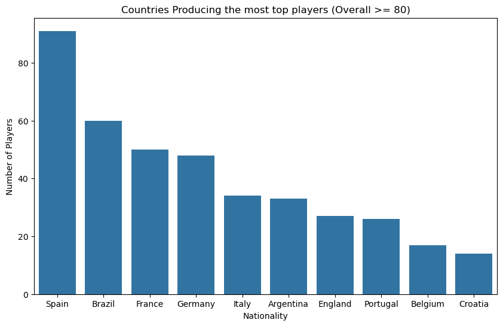

```python
#histogram of Overall ratings
import matplotlib.pyplot as plt
import seaborn as sns


top_10_countries = df_cleaned[df_cleaned['Overall'] >= 80]['Nationality'].value_counts().head(10)

data_to_plot = df_cleaned[(df_cleaned['Overall'] >= 80 ) & (df_cleaned['Nationality'].isin(top_10_countries.index))]
plt.figure(figsize=(10, 6))
sns.countplot(data=data_to_plot, x='Nationality', order=top_10_countries.index)
plt.title('Countries Producing the most top players (Overall >= 80)')
plt.xlabel('Nationality')
plt.ylabel('Number of Players')
plt.savefig('top_countries_overall_80.png')
plt.show()
```

```python
plt.savefig('top_countries_overall_80.png')
```

### 2. What ages do players tend to peak (overall rating vs age)

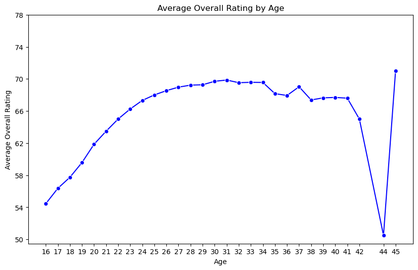

```python
#Line plot of average Overall rating by Age
age_overall = df_cleaned.groupby('Age')['Overall'].mean().reset_index()
plt.figure(figsize=(10, 6))
sns.lineplot(data=age_overall, x='Age', y='Overall', marker='o', color='b')
plt.title('Average Overall Rating by Age')
plt.xlabel('Age')
plt.ylabel('Average Overall Rating')
plt.xticks(age_overall['Age'])
plt.yticks(range(50, 80, 4))
plt.savefig('average_overall_by_age.png')
plt.show()
```